# Analyse de l'activité des paquets et dépôts R

Ce notebook a pour but de fournir quelques étapes (et le code associé) permettant de visualiser l'activité des dépôts et des paquets R. Dans un premier temps, nous chargeons les noms et propriétaires des dépôts R qui correspondent à un package R (autrement dit : qui ont un fichier `DESCRIPTION`). Ensuite, nous chargeons la liste des événéments du flux d'activités de chacun de ces dépôts, et nous comparons par groupe : les dépôts qui ne sont pas des packages, les dépôts qui sont des packages, les dépôts qui sont des packages SAUF ceux de cran et rpkg (deux *owner* particuliers).

## Chargement des données depuis les fichiers "description" des packages R

```python
import pandas
import numpy

%matplotlib inline

# Load from Maelick's data
df_description = pandas.read_csv('../data/github-description.csv')
```

```python
df_description.head()
```

|  | owner | repository | key | value |
| --- | --- | --- | --- | --- |
| 0 | 1beb | RGoogleDrive | Author | Brandon Bertelsen |
| 1 | 1beb | RGoogleDrive | Collate | \n'drive.auth.r'\n'drive.file.r'\n'drive.list.... |
| 2 | 1beb | RGoogleDrive | Date | 2013-12-02 |
| 3 | 1beb | RGoogleDrive | Description | This package implements the `get` and `list` f... |
| 4 | 1beb | RGoogleDrive | Imports | \nhttr,\nXML |

```python
df_packages = df_description[['owner', 'repository']].drop_duplicates()
df_packages.describe()
```

|  | owner | repository |
| --- | --- | --- |
| count | 19022 | 19022 |
| unique | 3655 | 11108 |
| top | cran | ggplot2 |
| freq | 5998 | 63 |

```python
# One could simply add labels for 'in_cran', 'in_rpkg', and 'in_other' for df_packages...
df_packages_cran = df_packages.query('owner == "cran"').copy()
df_packages_rpkg = df_packages.query('owner == "rpkg"').copy()
df_packages_others = df_packages.query('owner != "cran" and owner != "rpkg"').copy()
```

Quelques statistiques simples sur ces 3 groupes :

- cran possède 5998 dépôts
- rpkg possède 4409 dépôts (dont 4344 hébergent un package commun avec un dépôt cran)
- Il y a 8615 dépôts appartenant à d'autres personnes. Sur ces 8615 dépôts, 2420 sont des packages communs avec cran.

```python
import itertools

print 'cran: {}\trpkg: {}\tothers: {}'.format(len(df_packages_cran), len(df_packages_rpkg), len(df_packages_others))
combs = itertools.combinations([('cran', df_packages_cran), ('rpkg', df_packages_rpkg), ('others', df_packages_others)], 2)
for comb in combs:
    print '{}/{}:\t{}'.format(comb[0][0], comb[1][0], pandas.merge(comb[0][1], comb[1][1], on='repository').__len__())
```

```
cran: 5998	rpkg: 4409	others: 8615
cran/rpkg:	4344
cran/others:	2420
rpkg/others:	1507
```

## Chargement du flux d'activités

Nous allons extraire les informations du flux d'activités. En particulier, nous garderons :

- Le nom et le propriétaire du dépôt,
- Le type de l'événement,
- La date de l'événement

```python
import pymongo
import dateutil.parser
from itertools import imap

conn = pymongo.MongoClient()

def _from_json_to_flat(e):
    return {'type': e['type'],
            'actor': e['actor'],
            'created_at': dateutil.parser.parse(e['created_at']),
            'owner': e['repository']['owner'],
            'repository': e['repository']['name']}

events = imap(_from_json_to_flat,
              conn.r.events.find({'type': 'PushEvent'},
                                 fields=['type', 'actor', 'created_at', 'repository.name', 'repository.owner']))
```

```python
# This should take some time (expect 683425 items)
df_events = pandas.DataFrame(list(events))
```

```python
# Add flag to every packages in cran, rpkg, etc.
df_packages_cran['cran'] = 1
df_packages_rpkg['rpkg'] = 1
df_packages_others['other'] = 1

# Merge them all!
df_events_all = pandas.merge(df_events, df_packages_cran, how='left', on=('owner', 'repository'))
df_events_all = pandas.merge(df_events_all, df_packages_rpkg, how='left', on=('owner', 'repository'))
df_events_all = pandas.merge(df_events_all, df_packages_others, how='left', on=('owner', 'repository'))

# Date indexed
df_events_all.set_index('created_at', inplace=True)

df_events_all['all'] = 1
```

## Graphiquement...

- la courbe bleue correspond aux dépôts contenant un package R lié au compte cran,
- la courbe verte est invisible, mais elle correspond à un tout petit trait aux alentours d'avril 2014 (un peu avant le début de la courbe bleue) et correspond aux dépôts contenant un package R lié à rpkg,
- la courbe cyan correspond aux dépôts contenant un package R, qui n'appartient ni à rpkg, ni à cran.
- la courbe rouge correspond à l'ensemble de tous les dépôts liés à R.

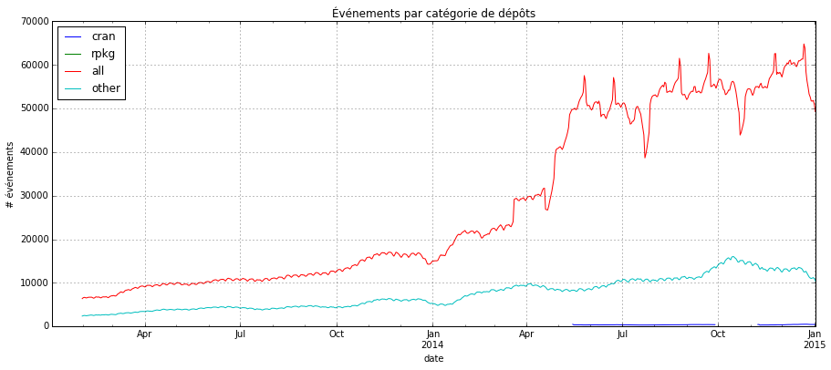

```python
df_temp = df_events_all.resample('1D', label='left', loffset='1d', how='sum')
plot = pandas.stats.moments.rolling_sum(df_temp, window=30)[['cran', 'rpkg', 'all', 'other']].plot()
plot.set_title(u'Événements par catégorie de dépôts')
plot.set_xlabel('date')
plot.set_ylabel(u'# événements')
plot.get_figure().set_size_inches(15,6)
```

Ou encore, l'*accélération* :

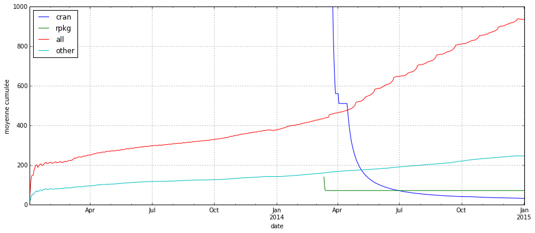

```python
plot = pandas.stats.moments.expanding_mean(df_temp)[['cran', 'rpkg', 'all', 'other']].plot()
plot.set_title=(u'Accélération du nombre d\'événements par catégorie de dépôts')
plot.set_ybound(upper=1000)
plot.set_xlabel('date')
plot.set_ylabel(u'moyenne cumulée')
plot.get_figure().set_size_inches(15,6)
```

## Activité des dépôts contenant un package sur CRAN et en dehors

Nous allons utiliser les informations collectées depuis CRAN afin d'identifier quels sont les packages R disponibles sur Github qui sont également présents sur CRAN. Cela nous permettra de comparer l'activité des dépôts qui sont liés à un package "officiel" de ceux qui ne le sont pas.

Pour procéder à cette identification, nous comparons le champ *Package* des fichiers `DESCRIPTION` des packages R de Github avec ceux de CRAN.

```python
# Load again from Maelick's data
df_description = pandas.read_csv('../data/github-description.csv')
df_cran = pandas.read_csv('../data/cran-description.csv')
```

```python
df_description = (df_description[df_description['key'] == 'Package']
                  .drop('key', axis=1)
                  .rename(columns={'value': 'package'}))

df_cran = (df_cran
           .drop_duplicates('package')
           .drop(['version', 'key', 'value'], axis=1))

df_cran['on_CRAN'] = 1
```

```python
# Merge and fill NaN with "0" for 'on_CRAN'
df_packages = df_description.merge(df_cran, how='left', on='package').fillna(0)
df_packages_events = df_packages.merge(df_events, how='inner', on=('owner', 'repository'))

# Prepare columns for easy plotting
df_packages_events.set_index('created_at', inplace=True)
df_packages_events['all'] = 1
df_packages_events['not_on_CRAN'] = 1 - df_packages_events['on_CRAN']
```

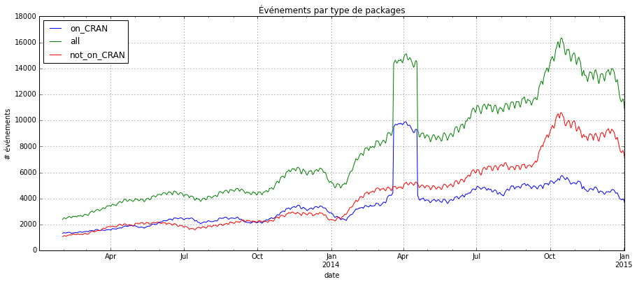

```python
df_temp = df_packages_events.resample('1D', label='left', loffset='1d', how='sum')
plot = pandas.stats.moments.rolling_sum(df_temp, window=30)[['on_CRAN', 'all', 'not_on_CRAN']].plot()
plot.set_title(u'Événements par type de packages')
plot.set_xlabel('date')
plot.set_ylabel(u'# événements')
plot.get_figure().set_size_inches(15,6)
```

Le petit "pic" en avril peut sans doute d'expliquer par l'import des packages depuis CRAN vers le compte cran sur Github (mirroring des packages). On peut filtrer cela.

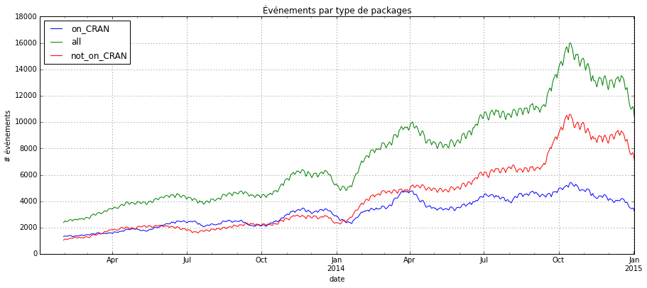

```python
df_temp = df_packages_events[df_packages_events['owner'] != 'cran'].resample('1D', label='left', loffset='1d', how='sum')
plot = pandas.stats.moments.rolling_sum(df_temp, window=30)[['on_CRAN', 'all', 'not_on_CRAN']].plot()
plot.set_title(u'Événements par type de packages')
plot.set_xlabel('date')
plot.set_ylabel(u'# événements')
plot.get_figure().set_size_inches(15,6)
```

Nous allons mesurer l'activité (et d'autres métriques) relative au nombre de dépôts et d'acteurs dans chaque catégorie. Pour se faire, nous comptons le nombre de dépôts (et d'acteurs) actifs pour chaque événement. Un dépôt (ou un acteur) actif est un dépôt pour lequel un événement a déjà été enregistré avant l'événement courant.

```python
# Sort the data according to created_at date
df_packages_events.sort(inplace=True)
```

```python
# Get first event for each repo and each actor
df_first_event_for_repository = df_packages_events.groupby(['owner', 'repository']).head(1).copy()
df_first_event_for_actor = df_packages_events.groupby('actor').head(1).copy()

# Isolate and enrich
df_first_event_for_repository['first_for_repo'] = 1
df_first_event_for_actor['first_for_actor'] = 1

# Merge
df_packages_events_first = df_packages_events.join(df_first_event_for_repository['first_for_repo']).join(df_first_event_for_actor['first_for_actor'])
```

```python
df_packages_events_first.fillna(value=0, inplace=True)

# I'm lazy...
t = df_packages_events_first
t['repo_CRAN'] = t['first_for_repo'] * t['on_CRAN']
t['repo_not_CRAN'] = t['first_for_repo'] * t['not_on_CRAN']
t['actor_CRAN'] = t['first_for_actor'] * t['on_CRAN']
t['actor_not_CRAN'] = t['first_for_actor'] * t['not_on_CRAN']
```

Les deux graphiques suivants montrent l'évolution du nombre de dépôts et du nombre d'acteurs dans le temps, par "communauté" (package sur CRAN / package pas présent sur CRAN), en se basant sur les événements pour déterminer ce nombre.

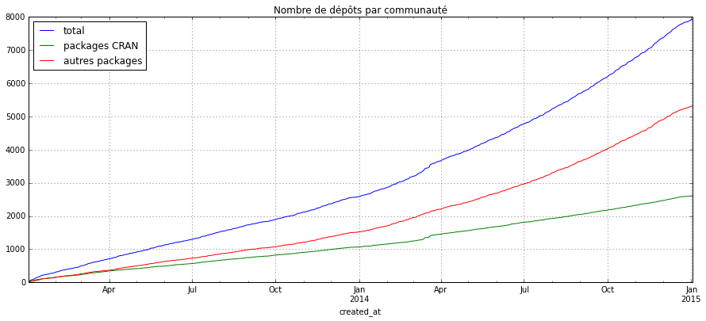

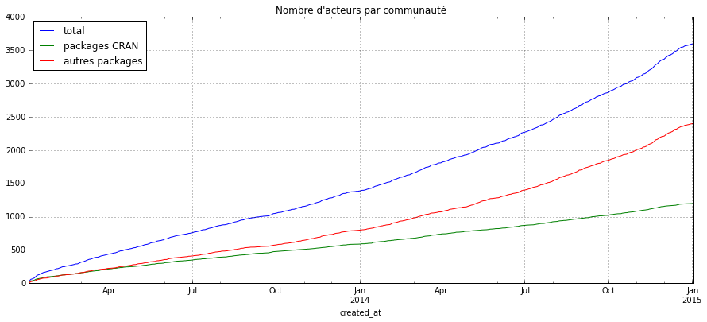

```python
df_temp = t[t['owner'] != 'cran'].resample('1D', label='left', loffset='1d', how='sum')
plot = pandas.stats.moments.expanding_sum(df_temp)[['first_for_repo', 'repo_CRAN', 'repo_not_CRAN']].plot(figsize=(15,6))
plot.set_title(u'Nombre de dépôts par communauté')
plot.legend([u'total', u'packages CRAN', u'autres packages'], loc='upper left')
plot = pandas.stats.moments.expanding_sum(df_temp)[['first_for_actor', 'actor_CRAN', 'actor_not_CRAN']].plot(figsize=(15,6))
plot.set_title(u'Nombre d\'acteurs par communauté')
plot.legend([u'total', u'packages CRAN', u'autres packages'], loc='upper left')
```

## Activité des dépôts "Hadley" en comparaison des autres

```python
hadley_repo_names = set(df_packages_events[df_packages_events['owner'] == 'hadley']['repository'])
```

```python
df_packages_events['hadley_related'] = df_packages_events['repository'].apply(lambda x: x in hadley_repo_names)
```

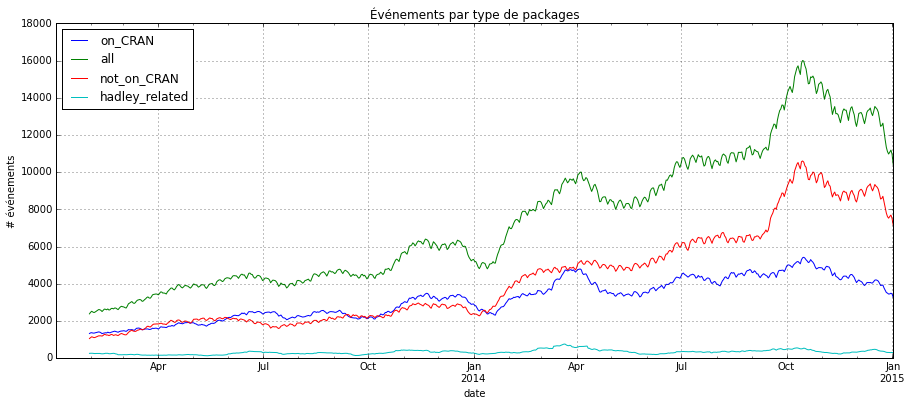

```python
df_temp = df_packages_events[df_packages_events['owner'] != 'cran'].resample('1D', label='left', loffset='1d', how='sum')
plot = pandas.stats.moments.rolling_sum(df_temp, window=30)[['on_CRAN', 'all', 'not_on_CRAN', 'hadley_related']].plot()
plot.set_title(u'Événements par type de packages')
plot.set_xlabel('date')
plot.set_ylabel(u'# événements')
plot.get_figure().set_size_inches(15,6)
```

## Activité en "forks" des dépôts sur GitHub : rdpeng - ProgrammingAssignement2

```python
def _from_json_to_flat(e):
    return {'type': e['type'],
            'actor': e['actor'],
            'created_at': dateutil.parser.parse(e['created_at']),
            'owner': e['repository']['owner'],
            'repository': e['repository']['name']}

events = imap(_from_json_to_flat,
              conn.r.events.find({'type': 'ForkEvent'},
                                 fields=['type', 'actor', 'created_at', 'repository.name', 'repository.owner']))
```

```python
df_fork_events = pandas.DataFrame(list(events))
```

```python
df_fork_events_all = pandas.merge(df_fork_events, df_packages_cran, how='left', on=('owner', 'repository'))
df_fork_events_all = pandas.merge(df_fork_events_all, df_packages_rpkg, how='left', on=('owner', 'repository'))
df_fork_events_all = pandas.merge(df_fork_events_all, df_packages_others, how='left', on=('owner', 'repository'))

# Date indexed
df_fork_events_all.set_index('created_at', inplace=True)

df_fork_events_all['all'] = 1
```

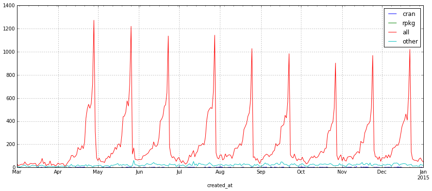

```python
df_temp = df_fork_events_all.resample('1D', label='left', loffset='1d', how='sum')
plot = df_temp['2014-03-01':'2015-01-01'][['cran', 'rpkg', 'all', 'other']].plot()
plot.get_figure().set_size_inches(15,6)
```

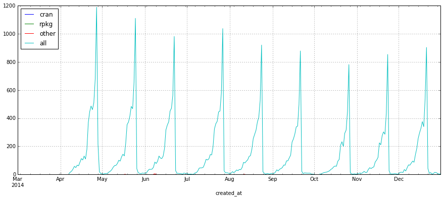

```python
df_fork_events_all[df_fork_events_all['owner']=='rdpeng'].resample('1D', how='sum')['2014-03-01':'2015-01-01'].plot(figsize=(15,6))
```